# Hate in Context

Week 3: Economic Causes and Hate Crime

Violeta Haas

Department of Political Science

School of Social Sciences and Philosophy

Trinity College Dublin

# This Week

1. Theoretical backdrop
2. Part I — Riaz (2023)
3. Part II — Bestenbostel & Peralta (2026)
4. Outlook

# Theoretical backdrop

## Which theory?

**David**

**Rose**

[figure not shown]

**Casey**

**Kenny**

## Group discussion (≈5 min)

**David**

**Rose**

[figure not shown]

**Casey**

**Kenny**

**In groups of 3-4:**

1. What does relative deprivation theory say?
2. How does this meme connect?

Submit your definition via TCDpolls: Blackboard → Week 03 → POU44653 Week 3: Relative Deprivation Theory

## Your Definitions

[Let’s take a look at your definitions!](https://tcdpolls.vevox.com/#/meeting/961829/polls)

## Relative deprivation theory

**Definition**

People feel deprived when they compare themselves (or their group) to a relevant standard and judge that gap as unfair (Pettigrew, 2016).

**Theory ingredients**

**In the meme**

A comparison to a relevant standard

Rose vs David’s $500k; Casey vs Rose’s $30k; Kenny vs anyone getting paid

An appraisal of disadvantage

“only giving me…” / “I’m only getting…” / “Wait you guys are getting paid?”

A sense that the gap is unjust → anger / resentment

The faces (Rose, Casey; Kenny’s shock)

Discontent tracks relative standing, not only absolute standing

## Relative deprivation theory

**What counts as a relevant standard**?

1. Other people — family (meme), coworkers, neighbors, peers
2. Other groups — “my group vs theirs”
3. One’s own past — “we used to have X”
4. Expectations/entitlement — what one thinks one deserves

→ RD also depends on which referent is salient (Walker & Pettigrew, 1984; Pettigrew, 2016).

# Part I — Riaz (2023)

## Dissecting the paper: 9 steps

Recall from Week 1 — when preparing a paper, identify:

1. Research question
2. What is explained (Y)
3. Main explanatory factor (X)
4. Theoretical argument/central concepts
5. Methods/research design
6. Main findings
7. Real-world implications
8. Contribution to the literature
9. Critique and limitations

## 1. Research question

Does inequality foster xenophobia?

**Puzzle:** Immigration triggers xenophobic backlash in some places but not others. Why?

**Riaz’s (2023) answer:** local economic inequality intensifies backlash against immigration.

## 2–3. Y and X

**Y (outcomes)**

- Xenophobic hate crimes (2012–2019)

**X (Treatment)**

- Refugee inflow in 2015

**Moderator**

- Local post-tax income inequality (Gini from 2010 tax registry)

Wait… what’s a moderator?

## Moderator vs mediator

**Moderator:** a factor that changes the strength (or direction) of the relationship between X and Y.

Here: refugee inflow → hate crime is stronger where inequality is high.

**Mediator:** a factor on the causal path from X to Y: X affects Y (partly) through it.

Example: parental education → child’s education → child’s income

## 4. Theoretical considerations

**Causal chain**

[figure not shown]

## Step 1: Inequality → relative deprivation

Local income inequality increases perceptions of relative deprivation (Walker & Pettigrew 1984):

**Theory ingredients**

**In Riaz (2023)**

A comparison to a relevant standard

Assumed: People in the same municipality compare on income

An appraisal of disadvantage

Assumed: For low-income natives, comparisons look worse where local inequality is high

A sense that the gap is unjust → anger/resentment

Assumed: That gap is pereived as unfair/grievance

Discontent tracks relative standing, not only absolute standing

Evidence: holding income constant, people in high-inequality municipalities report lower income satisfaction (SOEP)

→ Claim: when local inequality is high, relative deprivation is more pronounced and more frequent.

## Step 2: Relative deprivation → nationalism

Relative deprivation increases incentives for national (vs. class) identification (Shayo 2009).

> “The ordinary English worker hates the Irish worker as a **competitor who lowers his standard** of life. In relation to the Irish worker he regards himself as a **member of the ruling nation** and consequently he becomes a tool of the English aristocrats and capitalists against Ireland, thus strengthening their domination over himself. He cherishes religious, social, and national **prejudices against the Irish worker**. His attitude towards him is much the same as that of the ‘poor whites’ to [Black people] in the former slave states of the U.S.A. […] This antagonism is the secret of the impotence of the English working class […] It is the secret by which the capitalist class maintains its power.”

Karl Marx, letter to Sigfrid Meyer and August Vogt, 9 April 1870

## Why switch from class to nation?

The question is **which group provides higher status and feels more cohesive**

- Under high inequality, class (*“we workers”*) is a low-status identity for working-class natives
- Nation (*“we Germans/English”*) offers comparatively high status (Marx’s: *“regards himself as a member of the ruling nation”*)
- Refugee inflows change the composition of the working class: *“we workers”* now includes people who may feel culturally distant → class feels less cohesive
- National identity then wins: higher status esteem + more cohesive

**Argument**

→ Inequality is already there, refugees don’t create the status problem, but relatively low-income natives may perceive class identity less cohesive, so national identification increases.

## Step 3: Nationalism → stronger backlash

Nationalism and xenophobia in high-inequality places translate into more hate-crime:

- **Perpetrator pool:** higher xenophobia → more potential hate-crime offenders (attitudes are common among perpetrators, even if most xenophobes never offend)
- **Social environment:** communities with more xenophobic sentiment can make hate crime feel more “legitimate” or as acting “on behalf of” the community (see Dancigier et al. 2022, Dancygier 2023)

## 5. Methods/Research design

**(Self-)selection and confounding**

Places with more refugee arrivals often already differ.

**Self-selection**

- Refugees might choose places with jobs, co-ethnic networks, or a reputation for being welcoming

**Administrative selection**

- Authorities may send refugees to some municipalities and not others (e.g. available housing, or political considerations)

→ Hangartner et al. (2019) use geographic distance to Turkey as an instrument to guard against confounding introduced by (self-)selection.

**How does Riaz deal with this?**

Administrative Selection, is actually the solution…

- Germany’s quasi-exogenous allocation rules: refugees are allocated to municipalities largely proportional to population and independent of refugee individual traits → similar refugee intensity by design

## Local inequality

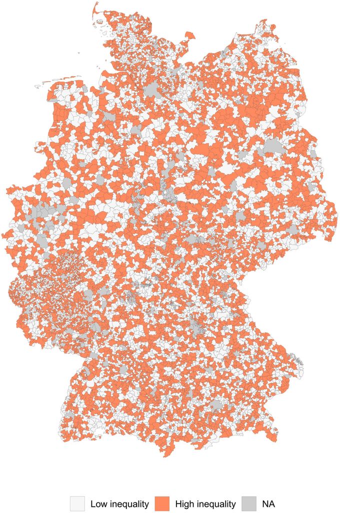

## 5. Difference-in-differences

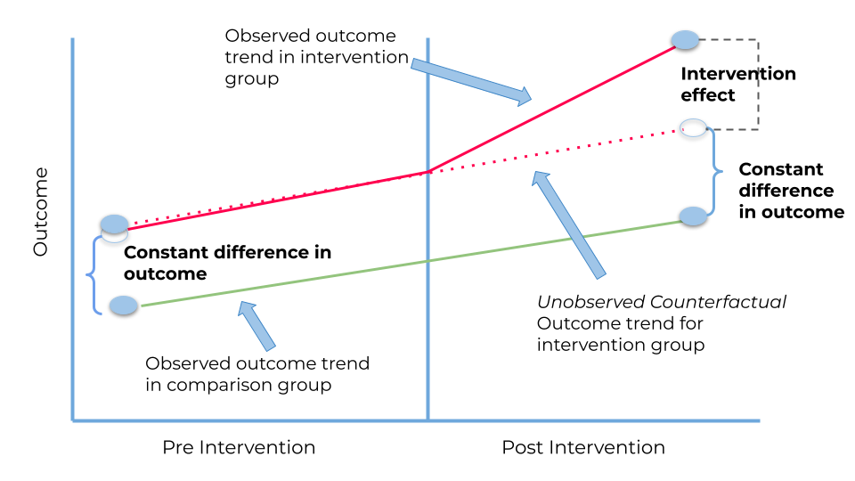

**In the graph**

**In Riaz (2023)**

Outcome

xenophobic hate crimes

Pre/post

before vs after 2015 refugee inflow

“Intervention” line (blue)

onset of the large-scale inflow (2015)

Intervention group (red)

high-inequality municipalities

Comparison group (green)

low-inequality municipalities

Counterfactual (dotted)

without-inflow path for high-inequality places (assumed)

Intervention effect

extra post-2015 rise in high- vs low-inequality places

## Parallel trends assumption

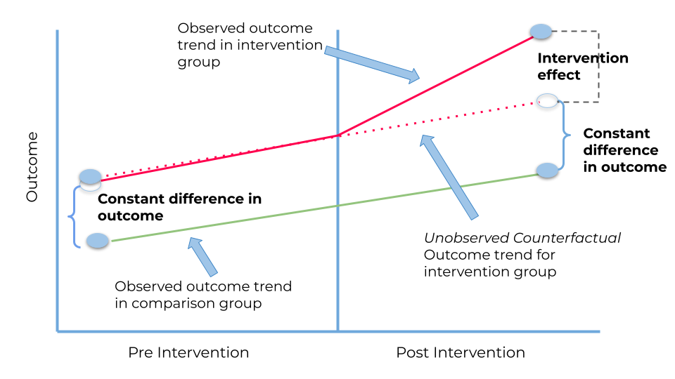

**Key assumption:**

absent the refugee inflow, hate-crime trajectories in high- and low-inequality places would have moved in parallel.

- In the figure: the “constant difference” and the dotted counterfactual
- Not testable! We cannot observe the counterfactual
- Partial check: do the two groups move in parallel before the inflow?

→ If parallel trends fail, the intervention effect could just be divergent pre-trends, not inequality moderating backlash.

## Figure 3: Hate crimes over time

**Does the partial check speak for parallel trends?**

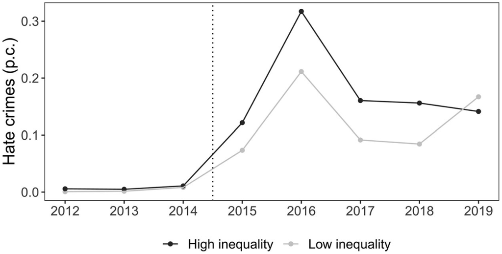

Pre-2015: paths between low- and high-income inequality regions look parallel. After 2015: stronger surge where inequality is high.

## 6. Findings

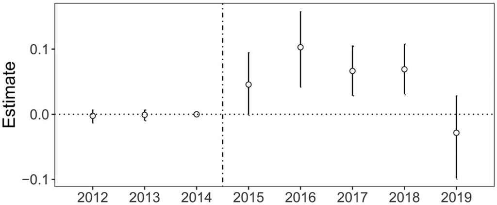

## 7–8. Implications & contributions

**Implications**

- Redistribution isn’t only about fairness in market incomes but may also be a tool against xenophobia
- Within-group relations (local inequality among natives) shape between-group conflict

**Contributions**

- Complements hate-crime literature on absolute hardship (unemployment, downturns) by showing relative standing also matters
- Adds xenophobic backlash to the broader literature on adverse political effects of inequality, i.e., (dis)engagement, etc.

## 9. Critique (≈5 min)

**In groups of 3–4:** - collect your critiques of Riaz (2023). Each group gives me your strongest point.

## Your Critique

What did not convince you?

## Some more Critique

Especially not in Germany

Relatively deprived individuals will not directly observe the income of their neighbours, peers, or co-workers.

## Never ask a German their income

United States

[interactive chart not shown]

[PBS backup](https://www.pbs.org/video/pay-equity-m8asd4/)

Germany

[video not shown]

[YouTube backup](https://www.youtube.com/watch?v=jC-ZZZE4dX0)

## What they see instead

**Status symbols, not pay slips:**

🚗 🏠 ✈️ ⌚ 👜 📱

- these track wealth, not only income
- So measured income inequality is an imperfect proxy for how people experience relative economic deprivation

# Part II — Bestenbostel & Peralta (2026)

## Bestenbostel & Peralta (2026) in a nutshell

Does news of impending mass layoffs cause racial animus?

**Setting & data**

- **Context:** US counties(2004–2018) hit by ~28k layoff notices (23 states)
- **Shock:** Worker Adjustment and Retraining Notification (WARN) mass-layoff/plant-closing notices (~60-day advance notice of ~100 workers on average)
- **Outcomes:** Google Trends racial-slur searches + FBI UCR hate crimes

**Design**

- Compare areas that differ in the *timing* of impending layoffs (county × month)
- Effects in the notice month → response to information, not yet realized job loss

**Findings**

- Racist searches ↑ ~1.4%; hate crimes ↑ ~1.2% after notices
- Strongest for anti-Black (and some anti-Hispanic) terms/crimes, while placebos (e.g. “weather”, anti-White slur) null
- Little anticipation in event studies; effect is contemporaneous with the notice

## A common outcome source: FBI UCR

[figure not shown]

FBI Uniform Crime Reporting (UCR) — Hate Crime Statistics

[FBI Hate Crime Statistics](https://www.fbi.gov/how-we-can-help-you/more-fbi-services-and-information/ucr/hate-crime)

## Why FBI UCR hate crime counts are imperfect

Official totals mix true incidence with who reports and what police record (true for most hate crime statistics).

### Under**reporting**

Victims (or witnesses) never tell the police / survey / platform

- Fear of retaliation
- Lack of trust in law enforcement
- Perceived ineffectiveness of reporting
- Limited awareness
- Inadequate reporting infrastructures
- Concerns about privacy

### Under**recording**

The event is known, but not flagged as hate crime

- Inconsistent definitions
- Inadequate recording infrastructure
- Lack of training
- Biases & stereotyping

→ Rising (or falling) UCR series can reflect reporting/recording change,not only more (or less) violence.

## But there is more problems…

- Two-step process: the first officer can flag a case if there is any sign of bias. Only a second, trained reviewer, can send it to the FBI → cases can be missed at either step
- Agency capacity varies: one trained reviewer vs a specialised unit → uneven review quality
- Motivation is subjective: needs “sufficient objective facts” that a “reasonable person” would see bias
- Voluntary participation → incomplete coverage (especially early years)

## Let’s all move to Miami?

[figure not shown]

ADL compilation of FBI Hate Crime Statistics (cities reporting zero or DNR).

## Policy advice (10-15min)

**Scenario.** The government has funding for precautionary measures to avoid spikes in hate crime. They have become aware of research linking economic conditions to bias-motivated crime and they are worried about **AI-driven job replacement**.

You are one of three advocacy organisations competing for the contract:

- Institute for Intergroup Safety (IIS)
- Alliance Against Bias Crime (AABC)
- Coalition for Hate Crime Prevention (CHCP)

**Your task** (3 Groups)

1. Design a short policy brief: what to worry about, what to fund, and why it should work. Draw on our readings.
2. Each group decide on one representative to pitch your brief (**2 minutes**).
3. Vote on who gets the job!

**A policy brief usually has…**

1. Title
2. Executive summary / recommendation
3. Problem / context
4. Evidence
5. Options
6. Preferred option
7. Implementation
8. Risks & caveats
9. Next steps

## Pitch

Your turn!

## Who gets the job?

- Institute for Intergroup Safety (IIS)
- Alliance Against Bias Crime (AABC)
- Coalition for Hate Crime Prevention (CHCP)

# Outlook

## Next week: (social) media

**Week 4** (Mon 5 / Wed 7 Oct): (social) media and hate crime.

**Required readings**

- Siegel, A. A. (2020). Online hate speech. In N. Persily & J. A. Tucker (Eds.), *Social media and democracy* (pp. 56–88). Cambridge University Press.
- Müller, K., & Schwarz, C. (2023). From hashtag to hate crime: Twitter and antiminority sentiment. *American Economic Journal: Applied Economics*, 15(3), 270–312.

Weekly comments due **Sunday 4 Oct, 11:59 pm**.

# Questions?

# Goodbye!

See you next week.